# Real data practical

First we need to make the data long-form:

```r
funimagery.long <- funimagery %>%
  pivot_longer(c(kg1, kg2, kg3)) %>%
  # use sep=2 to break name after the second character
  separate(name, into=c(NA, "time"), sep=2)
```

Then we can plot each timepoint using a facet:

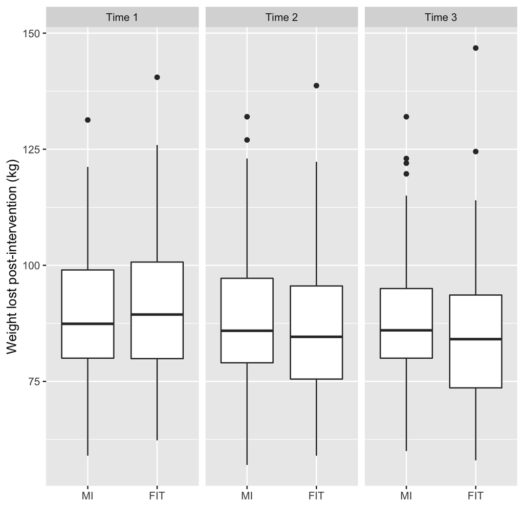

```r
funimagery.long %>%
  ggplot(aes(intervention, value)) +
  geom_boxplot() +
  labs(y="Weight lost post-intervention (kg)", x="") +
  # use `paste` to add the word 'time' in front of each number
  facet_grid(~paste("Time", time))
```

However, when we want to show the *average difference* between groups plotting the full range of data can be distracting. Sometimes, showing only the mean and standard error *is* what you want.

If so, a point-range plot is better. We can generate one using `stat_summary`, which is a bit like `summarise`, except that it applies a new graphic layer to a plot:

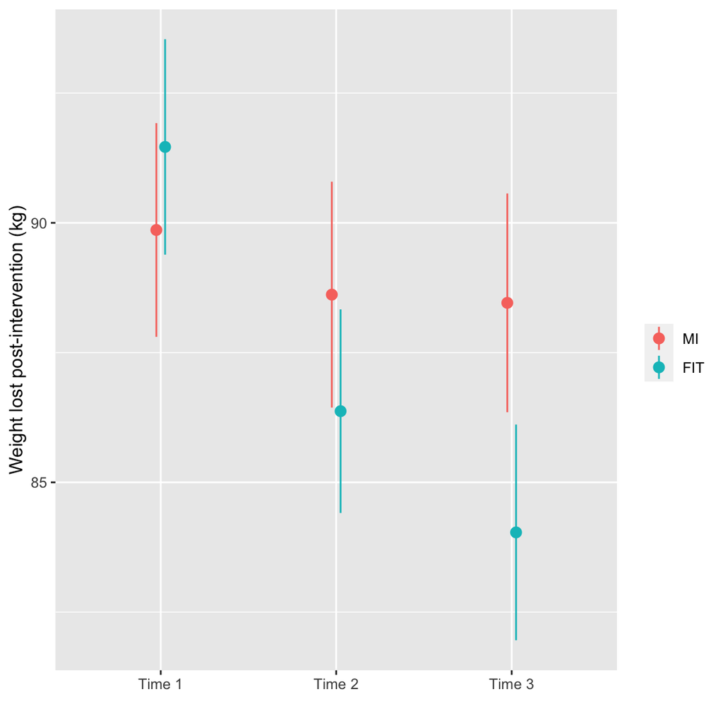

```r
funimagery.long %>%
  ggplot(aes(paste("Time", time), value, color=intervention)) +
  stat_summary(position=position_dodge(width=.1)) +
  labs(y="Weight lost post-intervention (kg)", x="", color="")
```

**Explanation of the code** We replaced `geom_boxplot` with `stat_summary`. In doing so I also set one of the options of `stat_summary`

- I added `position=position_dodge(width=.1)`. This offsets the MI and FIT data very slightly to make the plot more readable (remove it to see for your self the effect it has).

You can improve this plot again by connecting the dots:

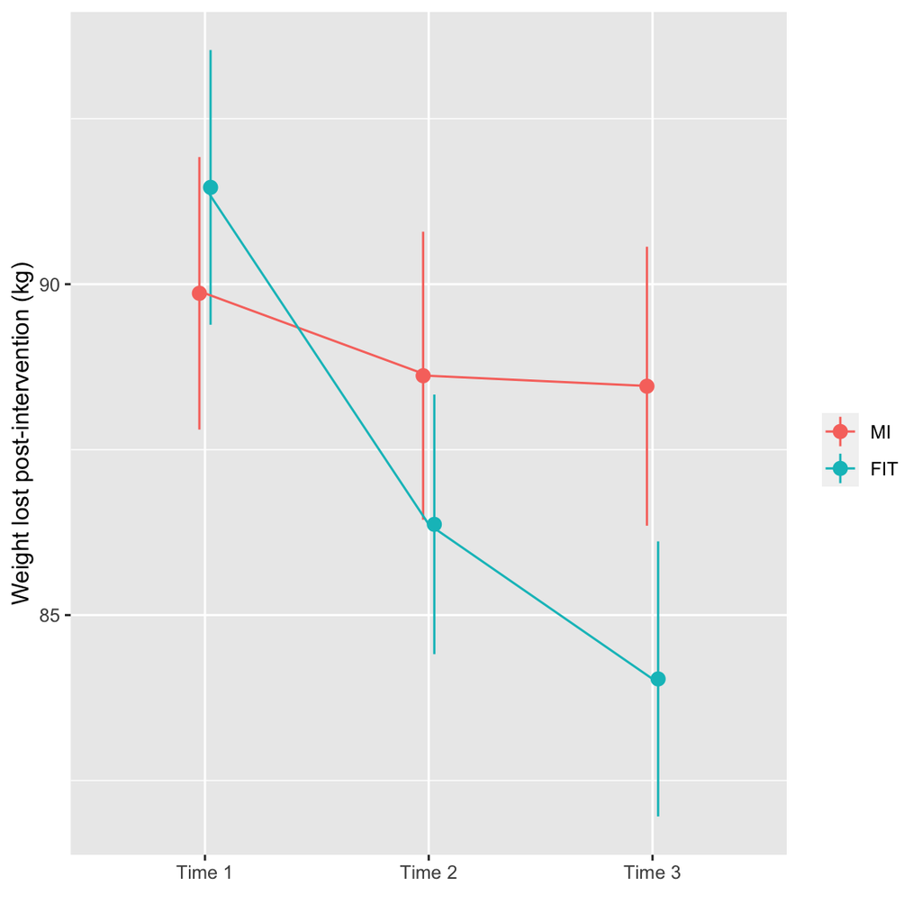

```r
# add the extra lines to the saved plot
previous.pointrange.plot +
  stat_summary(geom="line", aes(group=intervention))
```

**Explanation of the code**:

- `previous.pointrange.plot` is a stored copy of the previous ggplot (I stored the plot in this variable)
- I added an *extra* `stat_summary` layer
- In this layer I set `geom="line"` and wrote `aes(group=intervention)`. This adds lines for each intervention group.
- Recreate the boxplot and point-range plots shown above
- Create a new point-range plot using the `grass` dataset with `co2_uptake` on the y axis
- Add colour to that plot

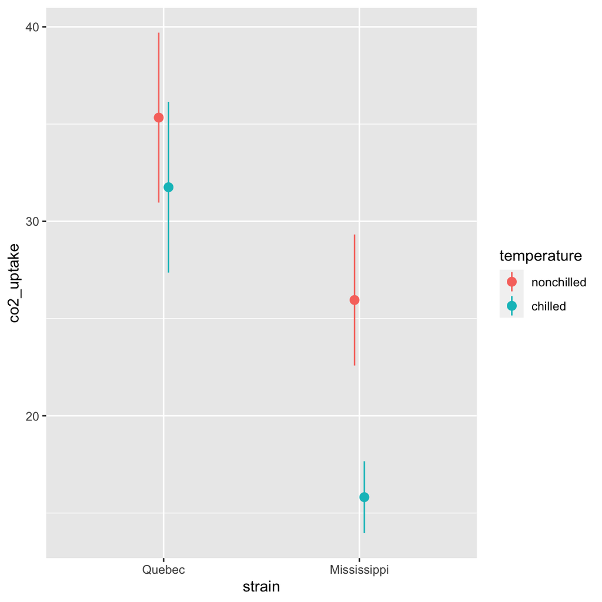

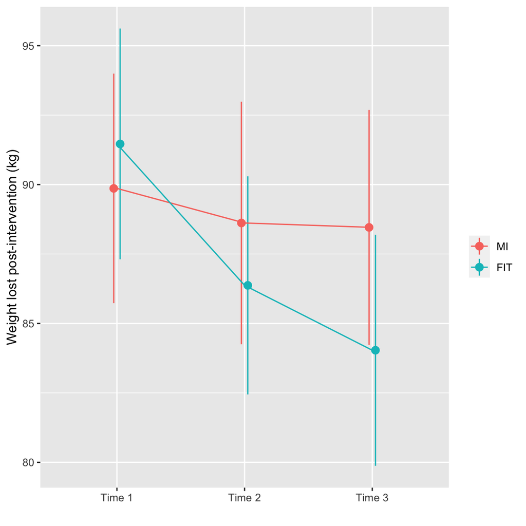

```r
funimagery.long %>%
  ggplot(aes(paste("Time", time), value, color=intervention)) +
  stat_summary(position=position_dodge(width=.1), fun.data = mean_cl_normal) +
  # connects the dots with lines for each intervention
  stat_summary(geom="line", aes(group=intervention)) +
  labs(y="Weight lost post-intervention (kg)", x="", color="")
```

# Adding lines to a plot

Sometimes it can be helpful to add lines to a plot: for example to show a clinically meaningful cut-off, or the median of a sample.

```r
median_income <-  earnings %>% summarise(median(income)) %>% pull(1)
```

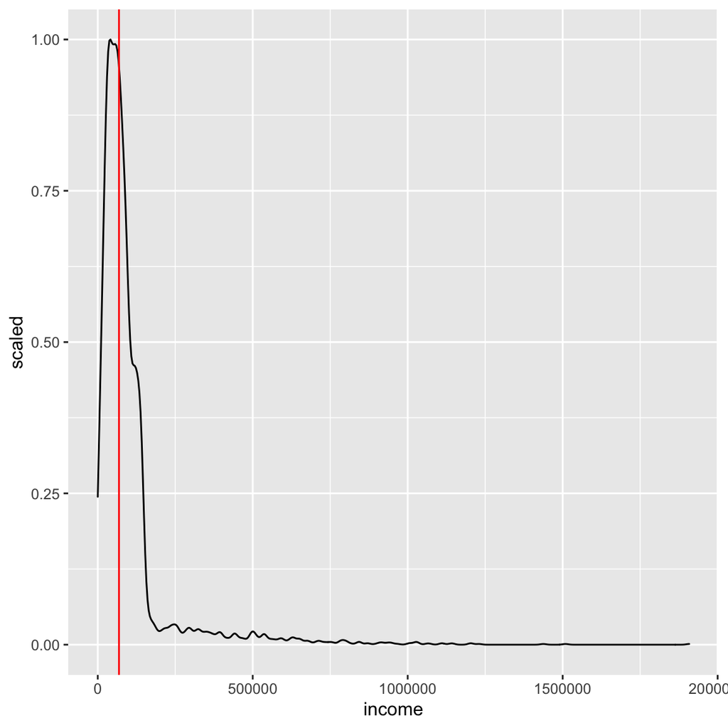

```r
earnings %>%
  ggplot(aes(income, y=..scaled..)) +
    geom_density() +
    geom_vline(xintercept = median_income, color="red")
```

**Explanation**: We have regular density plot. This time we have added `geom_vline` which draws a vertical line. The `xintercept` is the place on the x axis where our line should cross.

- Recreate the plot above
- Change the line to show the `mean` value in the sample

Add a `geom_vline` to a different plot you have already created. This could be either:

- A calculated value (e.g. `mean(var)`) or
- A fixed value (e.g. `xintercept = 20`)

You can also add horizontal lines using `geom_hline` and `yintercept=...`.

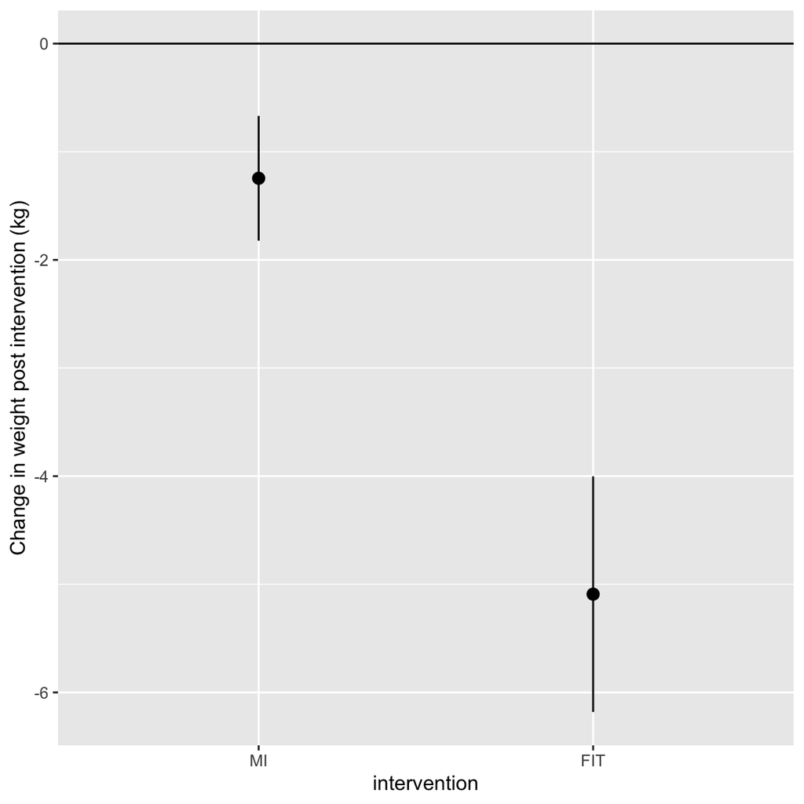

```r
funimagery %>%
  ggplot(aes(intervention, kg2-kg1)) +
  stat_summary(fun.data = mean_cl_normal) +
  geom_hline(yintercept = 0) +
  labs(y="Change in weight post intervention (kg)")
```

- Recreate the plot above
- Add a *second* line in blue to show the clinically-meaningful threshold of 1kg lost.

As a trickier (extension) exercise,

- Add a horizontal line in green to indicate a loss of 5% of bodyweight from baseline, on average. (Note that a 5% loss is also considered clinically relevant and would influence NICE decisions to fund a treatment).

# Egger 2019

The `egger2019` dataset in `psydata` is a copy of the SPSS file available at https://www.ncbi.nlm.nih.gov/pmc/articles/PMC6402646/bin/pone.0212482.s001.sav which reports data from Egger et al, 2019, *Boost your brain, while having a break! The effects of long-term cognitively engaging physical activity breaks on children’s executive functions and academic achievement*.

> Children were allocated to a 20-week exercise program, with either high physical exertion and high cognitive engagement (combo group), high physical exertion and low cognitive engagement (aerobic group), or low physical exertion and high cognitive engagement (cognition group).

The study outcomes included scores for maths (variables prefixed `hrt`), spelling (`hsp`) and reading (`sls`) scores were measured at two time points, before and after the intervention. For example, maths at time 1 was `hrt_t_wert_gesamt_1` and reading at time 2 was `sls_lq_2`.

In the dataset, study conditions 2, 3 and 4 in the dataset are respectively “aerobic”, “cognitive”, “combination”.

- Read in the data from the URL above using `import` from the `rio` package
- All the data you need are shown below. Create a new variable containing this subset of the data

```
Rows: 142
Columns: 9
$ id                   <dbl> 1, 2, 3, 4, 5, 6, 7, 8, 9, 10, 11, 12, 13, 14, 1…
$ condition            <dbl> 2, 2, 2, 2, 2, 2, 4, 4, 4, 4, 4, 4, 4, 4, 4, 4, …
$ gender               <dbl> 2, 2, 1, 1, 1, 1, 2, 2, 2, 1, 1, 2, 1, 1, 2, 1, …
$ hrt_t_wert_gesamt_1  <dbl> 50.28571, 47.85714, 64.71429, 65.71429, 56.85714…
$ hrt_t_wert_gesamt_2  <dbl> 59.57143, 44.42857, 62.14286, 70.42857, 54.85714…
$ hsp_graphem_t_wert_1 <dbl> 56, 56, 59, 64, 50, 49, 47, 44, 38, 66, 41, 46, …
$ hsp_graphem_t_wert_2 <dbl> 57, 48, 54, 67, 50, 44, 48, 44, 44, 50, 37, 42, …
$ sls_lq_1             <dbl> 117, 108, 123, 125, 86, 85, 86, 83, 83, 90, 78, …
$ sls_lq_2             <dbl> 139, 128, 139, 132, 97, 98, 104, 88, 98, 116, 88…
```

In the exercises which follow you will create a figure similar (but not identical) to that shown in Fig. 2 of the paper (see https://journals.plos.org/plosone/article/figure?id=10.1371/journal.pone.0212482.g002) and in Table 3 (see https://journals.plos.org/plosone/article/figure?id=10.1371/journal.pone.0212482.t003).

First you will need to reformat the data.

## Reformatting the data.

Use tidyverse commands including `pivot_longer`, `separate` and `mutate` to create the tables below. Each table is an *intermediate* step on the way to a data-format you can use to make the plot.

### Step 1

```
# A tibble: 12 x 4
      id condition name       value
   <dbl>     <dbl> <chr>      <dbl>
 1     1         2 gender       2
 2     1         2 maths_1     50.3
 3     1         2 maths_2     59.6
 4     1         2 spelling_1  56
 5     1         2 spelling_2  57
 6     1         2 reading_1  117
 7     1         2 reading_2  139
 8     2         2 gender       2
 9     2         2 maths_1     47.9
10     2         2 maths_2     44.4
11     2         2 spelling_1  56
12     2         2 spelling_2  48
```

You will need:

- `select`
- `rename`
- `pivot_longer`

### Step 2

```
# A tibble: 12 x 5
      id condition variable time  value
   <dbl> <fct>     <chr>    <chr> <dbl>
 1     1 aerobic   gender   <NA>    2
 2     1 aerobic   maths    1      50.3
 3     1 aerobic   maths    2      59.6
 4     1 aerobic   spelling 1      56
 5     1 aerobic   spelling 2      57
 6     1 aerobic   reading  1     117
 7     1 aerobic   reading  2     139
 8     2 aerobic   gender   <NA>    2
 9     2 aerobic   maths    1      47.9
10     2 aerobic   maths    2      44.4
11     2 aerobic   spelling 1      56
12     2 aerobic   spelling 2      48
```

You will need:

- `mutate` and `factor`
- `separate`

### Step 3

To produce this table you will need to use these functions: `group_by`, `summarise`, and `diff`.

Note: we haven’t used `diff` before, but like other functions like `mean` it accepts the name of a column to act on. It returns the *difference* between values in adjacent rows.

```
# A tibble: 6 x 4
# Groups:   id, condition, variable [6]
     id condition variable pre_post_difference
  <dbl> <fct>     <chr>                  <dbl>
1     1 aerobic   maths                   9.29
2     1 aerobic   reading                22
3     1 aerobic   spelling                1
4     2 aerobic   maths                  -3.43
5     2 aerobic   reading                20
6     2 aerobic   spelling               -8
```

Assuming you have data as expected from step 2:

```r
step3 <- step2 %>%
  group_by(id, condition, variable) %>%
  summarise(pre_post_difference = diff(value))
```

## Making the plot

Once you have the data from step 3 above, you should be able to make a plot like the one below:

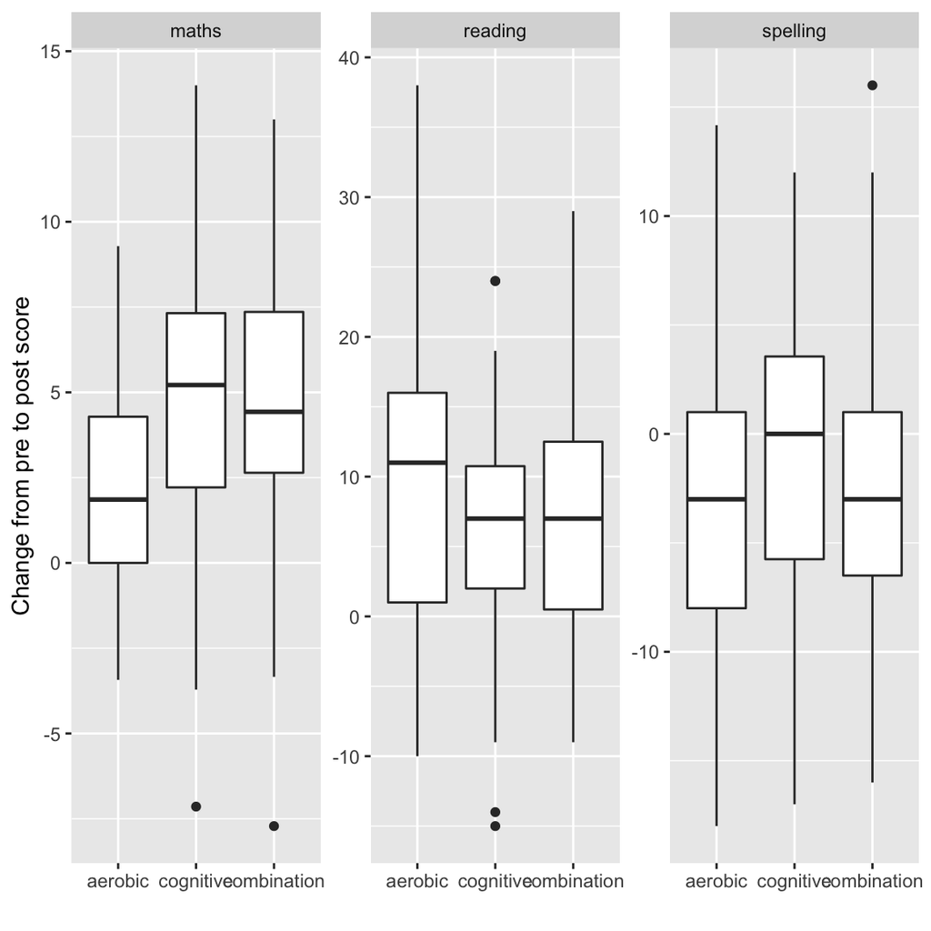

You will need:

- `ggplot`
- `aes`
- `geom_boxplot`
- `facet_grid` or `facet_wrap`
- `labs`

## Alternative plots

However as we saw above we can use point-range plots to plot these same data.

- Use `stat_summary` (as shown above) to plot the mean and standard errors, as shown in Egger Figure 2 (an example is shown below).

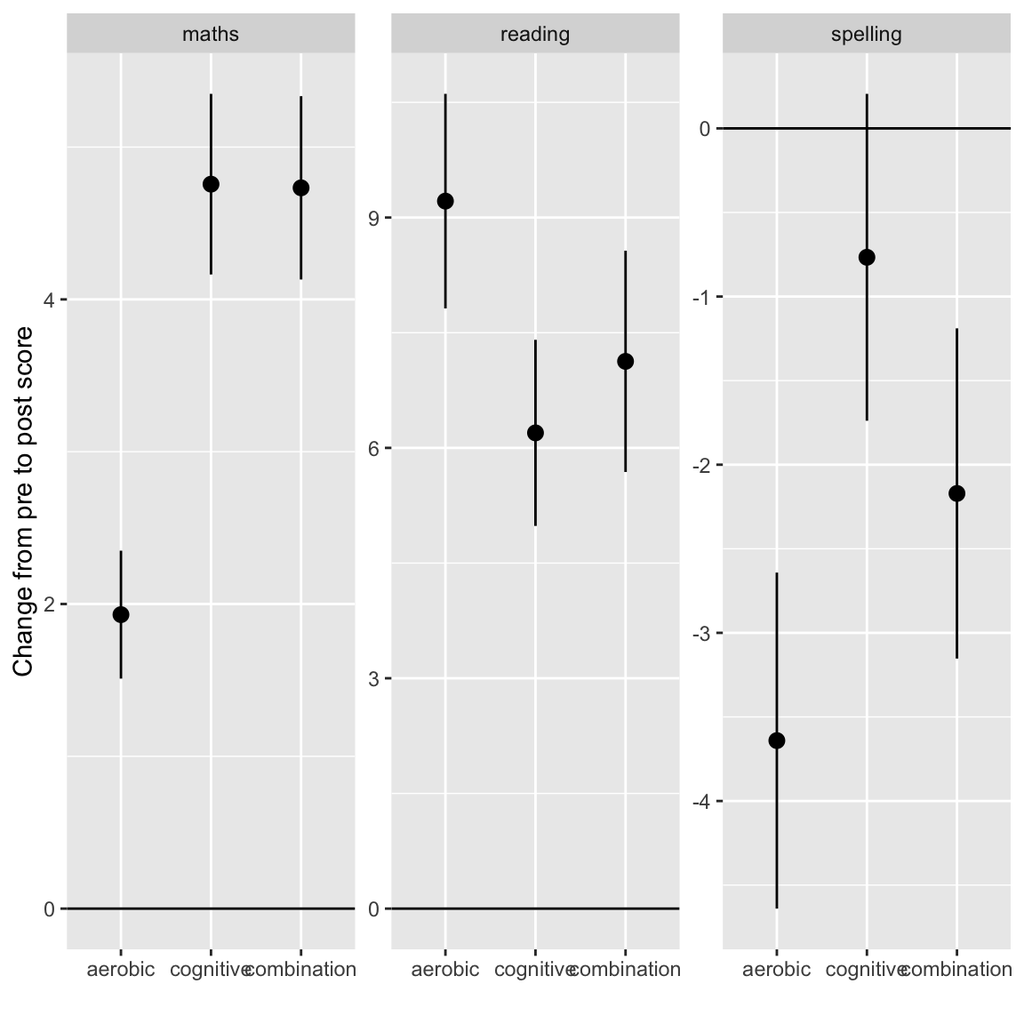

# Knitting RMarkdown

A neat feature of RMarkdown is that you can ‘knit’ your file to produce an finished HTML or PDF report. This combines:

- Your code
- The output of your code

So, your code becomes self-documenting. You can share both the `rmd` and the finished output.

### How to knit

You should see some messages whizzing by, and then an finished version of your report will appear.

You will have either an HTML file or PDF in the same directory as your Rmd file. This can be viewed/shared.

### How to fix the (inevitable) errors

Always remember: R is a dumb robot. It will do **exactly** what you say, even if that doesn’t make sense.

If you have errors when knitting check that *your code would work if you ran it in order from top to bottom*.

Especially check:

- You load libraries like tidyverse in the first chunk
- You import or create datasets BEFORE you use them

A good debugging technique is to go to the “Session” menu, and click “Restart R”.

Then go to the first chunk in your file and run each chunk in turn, fixing errors as they arise. Once you get to the bottom of the file with all errors fixed your Rmd file should knit.